# List 1

## Q1

On the first case, we have $F_1$:

$$F_1 = \frac{k Q^2}{R^2}$$

soon after, there was have reduction the charge in a half and distance doubled, staying:

$$ F_2 = \frac{k(\frac{Q}{2})^2}{(2R)^2} $$

simplifying:

$$ F_2 = \frac{1}{16} \frac{kQ^2}{R^2} $$

soon the relation of forces after $(F_2)$ and before $(F_1)$ is:

$$ F_2 = \frac{1}{16} F_1 $$

the modulo of the new force is the reduction in 16 part of the before force.

## Q2

first step:

$$ Q <-----(d_1)-----> 2Q <-----(d_2)-----> 4Q $$

for $2Q$ have resultant force null, the force of $Q$ in $2Q$ there is equal the force of $4Q$ in $2Q$, soon:

$$F_{12} = F_{32}$$

developing equality, we've

$$\frac{K*Q*2Q}{(d_1)^2} = \frac{K*2Q*4Q}{(d_2)^2}$$

soon, the relation d_1 and d_2 is :

$$ d_2 = 2d_1$$

## Q4

### a)

first step, we've to define the parameters

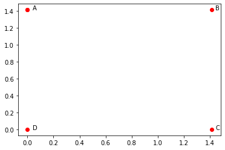

```python
from math import *
import numpy as np
import matplotlib.pyplot as plt
l = sqrt(2)
x = [0,l,l,0,0]
y = [l,l,0,0,l]

plt.plot(x,y,'ro')
# plt.plot(x,y)
plt.annotate("A", xy=(0+0.04,l))
plt.annotate("B", xy=(l+0.03,l))
plt.annotate("C", xy=(l+0.03,0))
plt.annotate("D", xy=(0+0.04,0))
```

second step is calculate to the force $B$ in $D$ :

$$\vec{F}_{BD} = \frac{k q^2}{(l\sqrt{2})^3} \vec{R}_{BD}$$

```python
k = 9e9
q = 1e-6

R_bd = (l*sqrt(2))
b = (k*q**2)/(R_bd**3) #escalar


r_bd = np.array([-l,-l])

F_bd = b*r_bd
print('F_bd = {:.2e}*i {:.2e}*j'.format(*F_bd))
```

```
F_bd = -1.59e-03*i -1.59e-03*j
```

third step, calculate to the force $A$ in $D$:

$$\vec{F}_{AD} = \frac{k q^2}{l^3} \vec{R}_{AD}$$

```python
R_ad = l
r_ad = np.array([0,-l])

b = (k*q**2)/(R_ad**3) #escalar
F_ad = b*r_ad

print('F_ad = {:.2e}*i {:.2e}*j'.format(*F_ad))
```

```
F_ad = 0.00e+00*i -4.50e-03*j
```

fourth step, calculate to the force $C$ in $D$ :

$$\vec{F}_{CD} = \frac{k q^2}{l^3} \vec{R}_{CD}$$

```python
R_cd = l
r_cd = np.array([-l,0])

b = (k*q**2)/(R_cd**3) #escalar

F_cd = b*r_cd

print('F_cd = {:.2e}*i {:.2e}*j'.format(*F_cd))
```

```
F_cd = -4.50e-03*i 0.00e+00*j
```

fiveth and last step, calculate to the result force in $D$ :

$$\vec{F_D} = \vec{F}_{BD}+\vec{F}_{CD}+\vec{F}_{AD}$$

```python
F_d = F_bd+F_cd+F_ad

print('F_d = {:.2e}*i {:.2e}*j'.format(*F_d))
```

```
F_d = -6.09e-03*i -6.09e-03*j
```

### b)

the components of force in square center gonna annul, with it the result force will be zero.

## Q5

first step, setting the parameters:

```python
q1 = 2e-6
q2 = -300e-6

P1 = np.array([0,1,2])
P2 = np.array([2,0,0])

R21 = np.array([P1 - P2][0]) #vector P21

r21 = sqrt(sum(R21**2)) #modulo

print('R21 = {:.2e}*i {:.2e}*j {:.2e}*k'.format(*R21))
```

```
R21 = -2.00e+00*i 1.00e+00*j 2.00e+00*k
```

we've:

```python
F21 = ((k*q1*q2)/r21)*R21
print('F21 = {:.2e}*i {:.2e}*j {:.2e}*k'.format(*F21))
```

```
F21 = 3.60e+00*i -1.80e+00*j -3.60e+00*k
```

## Q6

### a)

first step, putting on the input

```python
Qa = 200e-6
Qb = 500e-6
A = np.array([26,4,7])
B = np.array([5,8,-2])

Rab = np.array([B-A][0])


print('Rab = {:.2e}*i {:.2e}*j {:.2e}*k'.format(*Rab))
```

```
Rab = -2.10e+01*i 4.00e+00*j -9.00e+00*k
```

### b)

Calculating the vector modulo of $\vec{R}_{AB}$

```python
rab = sqrt(sum(Rab**2))
rab
```

```
23.194827009486403
```

the force is:

```python
Fab = ((Qa*Qb)/(4*pi*(1e-9/(36*pi)*rab)))*Rab

print('Fab = {:.2e}*i {:.2e}*j {:.2e}*k'.format(*Fab))
```

```
Fab = -8.15e+02*i 1.55e+02*j -3.49e+02*k
```

## Q7

putting on the input:

```python
q = 2e-6
F = 0.1
```

$$ d = \sqrt{\frac{k * Q^2}{F}}$$

```python
d = sqrt((k*q**2)/F)
d
```

```
0.6
```

soon:

$$ d = 0.6 m$$

## Q3

first step:

$$ Q_1 <-------(x)-------> Q_3 <-------(d-x)-------> Q_2$$

for have a balanced system $\vec{F}_{13} = \vec{F}_{23}$

$$\frac{ k * q_1 * q_2}{x^2} = \frac{ k * q_2 * q_3}{(d-x)^2}$$

simplifying: $$ \frac{d-x}{x} = \sqrt{\frac{q_2}{q_1}}$$

```python
q1 = -9e-6
q2 = -36e-6

b = sqrt(q2/q1) + 1 #b = d/x
b
```

```
3.0
```

soon we stay with: $ \frac{d}{x} = 3 \rightarrow d = 3x $, we've always that proportion of $1$ to $3$

looking now for the balanced system in $Q_2$: $$ \vec{F}_{32} = \vec{F}_{12} $$

$$\frac{ k * q_3 * q_2}{(d-x)^2} = \frac{ k * q_1 * q_2}{d^2}$$

$$ q_3 = q_1 \frac{(d-x)^2}{d^2}$$

```python
x = 1 # arbitrary value for calculate
d=3*x
q3 = q1*(((d-x)**2)/(d**2))
q3
```

```
-4e-06
```

soon $$ q_3 = -4\mu C$$